# Exploración de expresión génica en Phaseolus vulgaris

Acevedo Sandoval Tomás Tonaltsintle

2025-10-27

## Donde se optuvieron los datos: Project: PRJNA1049907 https://www.ebi.ac.uk/ena/browser/view/PRJNA1049907

## el titulo del proyecto es “Phosphate Starvation Response 1 controls nodule formation in Phaseolus vulgaris”

# INTRODUCCION

### La deficiencia de fósforo (Pi) reduce la formación de nódulos en Phaseolus vulgaris, lo que impacta la fijación de nitrógeno. PvPHR-LIKE 7 es un factor de transcripción tipo PHR que regula genes involucrados en la simbiosis de raíces bajo diferentes niveles de Pi. PvPHR-L7 puede actuar como regulador negativo de la formación de nódulos y controla la expresión de genes clave

#PREGUNTAS ¿Cómo afecta la sobreexpresión o silenciamiento de PvPHR-LIKE 7 en la expresión génica de Phaseolus vulgaris? ¿Qué genes muestran la mayor variabilidad de expresión y podrían estar regulados por PvPHR-LIKE 7?

#HIPOTESIS La sobreexpresión o silenciamiento de PvPHR-LIKE 7 afecta de forma diferencial la expresión de genes en deficiencia de Pi

#VARIABLES Treatamiento 3 niveles: RNAi (silenciamiento), Ox (sobreexpresión), EV 2 estados de fósforo: OPI (óptimo), LPI (bajo)

## Las variables analizadas

RNAi_OPI, OPI, RNAi RNAi_LPI, LPI, RNAi EV_OPI, OPI, EV EV_LPI, LPI, EV Ox_OPI, OPI, Ox Ox_LPI, LPI, Ox

### las cuales estan contenidas en las siguientes repeticiones

### “SRR27137980”, “SRR27137981”, “SRR27137982”, “SRR27137983”, “SRR27137984”, “SRR27137985”, “SRR27137986”, “SRR27137987”, “SRR27137988”, “SRR27137989”,“SRR27137990”, “SRR27137991”, “SRR27137992”, “SRR27137993”, “SRR27137994”,“SRR27137995”, “SRR27137996”, “SRR27137997

# Sección 1: Preparación y configuración

# ===========================================================================

## 1.1: Instalación de Paquetes (si es necesario)

# ===========================================================================

```r
#install.packages("tidyverse")                                                   ## Comprovado
#install.packages("here")
#install.packages("fs")
#install.packages("pheatmap")
#install.packages("patchwork")
#install.packages("knitr")
#install.packages("rmarkdown")
#install.packages("ggpubr")
#install.packages("RColorBrewer")
#install.packages("plotly")
#install.packages("BiocManager")# Instalar el gestor de paquetes de Bioconductor
#install.packages("rgbif")
#install.packages("sf")
#install.packages("rworldxtra")
#install.packages("geodata")
#install.packages("ggspatial")
#install.packages("terra")
#install.packages("tidyterra")
#install.packages("paletteer")
#install.packages("ggcorrplot")
#install.packages("ggridges")
#install.packages("magick")
#BiocManager::install("tximport")
#BiocManager::install("DESeq2")
```

# ===========================================================================

## 1.2: Carga de librerias

# ===========================================================================

```r
# Paquetes de CRAN
library(tidyverse)    # Manipulación (dplyr, tidyr), lectura (readr), gráficos (ggplot2)
library(here)         # Gestión de directorios
library(fs)           # Herramientas para trabajar con el sistema de archivos (crear directorios, gestionar archivos)
library(pheatmap)     # Genera heatmaps para visualizar expresión génica
library(patchwork)    # Combina múltiples gráficos de ggplot2 en una sola figura
library(knitr)        # Tablas dinámicas
library(rmarkdown)    # Genera informes dinámicos y formateados, útil para RMarkdown
library(ggpubr)       # Simplifica la creación de gráficos de publicación con ggplot2
library(RColorBrewer) # Proporciona paletas de colores optimizadas para visualizaciones
library(rgbif) #descargar datos de ocurrencias
library(sf) #manipulaci?n  de datos vectoriales
library(rworldxtra) #datos vectoriales de los paises del mundo
library(geodata) #datos geoespaciales complemenatarios
library(ggspatial)#auxiliar para visualizar datos espaciales
library(terra) #datos raster
library(tidyterra) #maniipulaci?n de raster
library(paletteer) #colores
library(ggcorrplot) #diagrama de correlaciones
library(ggridges) #gr?fico de ridges
library(plotly) #gr?ficos avanzados
library(magick) #para manejo de imagenes
# Paquetes de Bioconductor
library(tximport)     # Para importar Salmon
library(DESeq2)       #Realiza análisis de expresión diferencial y normalización de datos de RNA-seq  ## Comprovado
```

# ===========================================================================

## 1.3: Creación de Directorios

# ===========================================================================

```r
getwd() #Comprovando direccion de carpeta
```

```
## [1] "F:/proyecto_final/proyecto/Proyecto_final_Exploraci-n-de-expresi-n-g-nica-"
```

```r
#Generando las carpetas
#dir_create sirve para crear una carpeta en tu sistema de archivos.
dir_create("datos")        # Para archivos TSV
dir_create("scripts")      # Para scripts .R
dir_create("salidas")      # Para resultados
dir_create("salidas_data") # Para datos procesados                          ##comprovado
```

# ===========================================================================

## 1.4: Creación de Lista de Muestras y Rutas)

# ===========================================================================

```r
# Creación de un vectror de caracteres  de los nombre de la Lista de Muestras (solo son los nombres! sin rutas)
#mis archivos se llaman SRR27137980.fastq.gz... etc... y R con el paquete de salmon agregara a los nombres asignados las extenciones "fastq.gz"
samples <- c("SRR27137980", "SRR27137981", "SRR27137982", "SRR27137983", "SRR27137984",
             "SRR27137985", "SRR27137986", "SRR27137987", "SRR27137988", "SRR27137989",
             "SRR27137990", "SRR27137991", "SRR27137992", "SRR27137993", "SRR27137994",
             "SRR27137995", "SRR27137996", "SRR27137997")
print(samples)
```

```
##  [1] "SRR27137980" "SRR27137981" "SRR27137982" "SRR27137983" "SRR27137984"
##  [6] "SRR27137985" "SRR27137986" "SRR27137987" "SRR27137988" "SRR27137989"
## [11] "SRR27137990" "SRR27137991" "SRR27137992" "SRR27137993" "SRR27137994"
## [16] "SRR27137995" "SRR27137996" "SRR27137997"
```

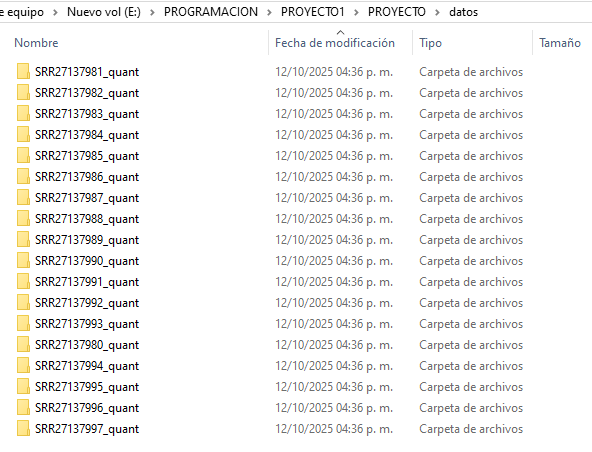

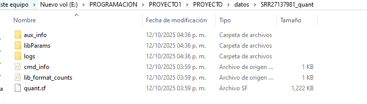

# =========================================================================== ## 1.5 : Rutas a archivos de Salmon (quant.sf) # ===========================================================================

```r
#Para cada elemento del vector samples, agrega la cadena "_quant"
#here("datos") devuelve la ruta absoluta a la carpeta datos
#file.path() arma rutas de archivos
files <- file.path(here("datos"), paste0(samples, "_quant"), "quant.sf")
#despues se asignan nombres a cada elemento del vector files usando el vector samples.
names(files) <- samples
#Verificación de Existencia de Archivos                     ##comprobado = todos TRUE, fueron creados correctamente
file.exists(files)
```

```
##  [1] TRUE TRUE TRUE TRUE TRUE TRUE TRUE TRUE TRUE TRUE TRUE TRUE TRUE TRUE TRUE
## [16] TRUE TRUE TRUE
```

```r
#Para ver la ruta completa
str(files)
```

```
##  Named chr [1:18] "F:/proyecto_final/proyecto/Proyecto_final_Exploraci-n-de-expresi-n-g-nica-/datos/SRR27137980_quant/quant.sf" ...
##  - attr(*, "names")= chr [1:18] "SRR27137980" "SRR27137981" "SRR27137982" "SRR27137983" ...
```

# ===========================================================================

## 1.6: Generacion de Metadatos

# ===========================================================================

```r
#Relacion los nombres de los archivos y la información experimental.
#DESeq2 necesita un objeto colData (metadatos) que tenga nombres de columnas iguales a tus muestras
metadata <- tibble(
  Sample = c("SRR27137980", "SRR27137981", "SRR27137982", "SRR27137983", "SRR27137984",
             "SRR27137985", "SRR27137986", "SRR27137987", "SRR27137988", "SRR27137989",
             "SRR27137990", "SRR27137991", "SRR27137992", "SRR27137993", "SRR27137994",
             "SRR27137995", "SRR27137996", "SRR27137997"),
  Condition = c("RNAi_OPI", "RNAi_LPI", "RNAi_LPI", "RNAi_LPI", "EV_OPI",
                "EV_OPI", "EV_OPI", "EV_LPI", "Ox_OPI", "Ox_OPI",
                "Ox_OPI", "Ox_LPI", "Ox_LPI", "Ox_LPI", "RNAi_OPI",
                "RNAi_OPI", "EV_LPI", "EV_LPI"),
  Pi_Status = c("OPI", "LPI", "LPI", "LPI", "OPI",
                "OPI", "OPI", "LPI", "OPI", "OPI",
                "OPI", "LPI", "LPI", "LPI", "OPI",
                "OPI", "LPI", "LPI"),
  Treatment = c("RNAi", "RNAi", "RNAi", "RNAi", "EV",
                "EV", "EV", "EV", "Ox", "Ox",
                "Ox", "Ox", "Ox", "Ox", "RNAi",
                "RNAi", "EV", "EV"),
  Replicate = c(1, 3, 2, 1, 3,
                2, 1, 3, 3, 2,
                1, 3, 2, 1, 3,
                2, 2, 1)
)
# Guardar en la raíz el tibble como archivo CSV.
write_csv(metadata, here("samples.csv"))
```

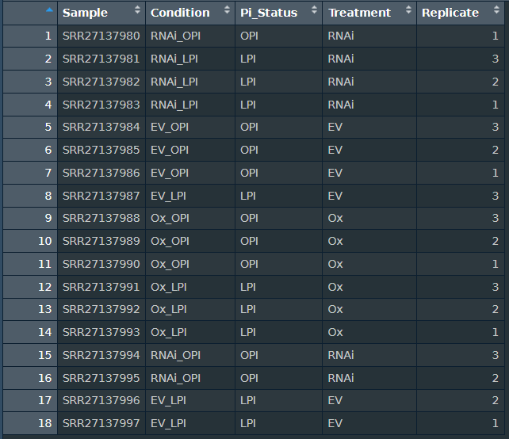

# ===========================================================================

## 1.7: Carga y verificación de metadatos

# ===========================================================================

```r
#Revisar el estado de la tabla samples.csv (metadatos)
metadata <-  read_csv(here ("samples.csv")) #se esta leyendo como un tibble
summary(metadata)
```

```
##     Sample           Condition          Pi_Status          Treatment
##  Length:18          Length:18          Length:18          Length:18
##  Class :character   Class :character   Class :character   Class :character
##  Mode  :character   Mode  :character   Mode  :character   Mode  :character
##
##
##
##    Replicate
##  Min.   :1
##  1st Qu.:1
##  Median :2
##  Mean   :2
##  3rd Qu.:3
##  Max.   :3
```

```r
view(metadata)
head(metadata)
```

```
## # A tibble: 6 × 5
##   Sample      Condition Pi_Status Treatment Replicate
##   <chr>       <chr>     <chr>     <chr>         <dbl>
## 1 SRR27137980 RNAi_OPI  OPI       RNAi              1
## 2 SRR27137981 RNAi_LPI  LPI       RNAi              3
## 3 SRR27137982 RNAi_LPI  LPI       RNAi              2
## 4 SRR27137983 RNAi_LPI  LPI       RNAi              1
## 5 SRR27137984 EV_OPI    OPI       EV                3
## 6 SRR27137985 EV_OPI    OPI       EV                2
```

```r
getwd()  # Verificar working directory "E:/PROGRAMACION/PROYECTO1/PROYECTO"
```

```
## [1] "F:/proyecto_final/proyecto/Proyecto_final_Exploraci-n-de-expresi-n-g-nica-"
```

# ===========================================================================

## 1.8: Conversión a data.frame

# ===========================================================================

```r
# Se necesita ya que DESeq2 funciona con data.frames
metadata_df <- as.data.frame(metadata) # Convertir a data frame
row.names(metadata_df) <- metadata_df$Sample #los nombres de fila del data.frame seran los nombres de muestra
metadata_df$Sample <- NULL  # Remover columna Sample (ya no se necesita)
```

# ===========================================================================

## 1.10: Verificar la estructura de metadata

# ===========================================================================

```r
# Estructura final
str(metadata_df)
```

```
## 'data.frame':    18 obs. of  4 variables:
##  $ Condition: chr  "RNAi_OPI" "RNAi_LPI" "RNAi_LPI" "RNAi_LPI" ...
##  $ Pi_Status: chr  "OPI" "LPI" "LPI" "LPI" ...
##  $ Treatment: chr  "RNAi" "RNAi" "RNAi" "RNAi" ...
##  $ Replicate: num  1 3 2 1 3 2 1 3 3 2 ...
```

```r
head(metadata_df)
```

```
##             Condition Pi_Status Treatment Replicate
## SRR27137980  RNAi_OPI       OPI      RNAi         1
## SRR27137981  RNAi_LPI       LPI      RNAi         3
## SRR27137982  RNAi_LPI       LPI      RNAi         2
## SRR27137983  RNAi_LPI       LPI      RNAi         1
## SRR27137984    EV_OPI       OPI        EV         3
## SRR27137985    EV_OPI       OPI        EV         2
```

```r
head(rownames(metadata_df))
```

```
## [1] "SRR27137980" "SRR27137981" "SRR27137982" "SRR27137983" "SRR27137984"
## [6] "SRR27137985"
```

# Sección 2: Importación y procesamiento de datos crudos

# ===========================================================================

## 2.1 : Importación con tximport

# ===========================================================================

```r
# Importar con tximport (nivel transcrito)
#función principal para leer los resultados de cuantificación de transcritos desde Salmon
#txOut mantiene los datos a nivel de transcrito
#se generara una lista que contiene las matrices
txi <- tximport(files, type = "salmon", txOut = TRUE)
```

```
## reading in files with read_tsv
```

```
## 1 2 3 4 5 6 7 8 9 10 11 12 13 14 15 16 17 18
```

```r
print(paste("Dimensiones TPM:", dim(txi$abundance))) #tamaño de las matrices
```

```
## [1] "Dimensiones TPM: 32131" "Dimensiones TPM: 18"
```

```r
print(paste("Dimensiones Counts:", dim(txi$counts)))
```

```
## [1] "Dimensiones Counts: 32131" "Dimensiones Counts: 18"
```

```r
colnames(txi$abundance)[1:18] #tamaño de las matrices
```

```
##  [1] "SRR27137980" "SRR27137981" "SRR27137982" "SRR27137983" "SRR27137984"
##  [6] "SRR27137985" "SRR27137986" "SRR27137987" "SRR27137988" "SRR27137989"
## [11] "SRR27137990" "SRR27137991" "SRR27137992" "SRR27137993" "SRR27137994"
## [16] "SRR27137995" "SRR27137996" "SRR27137997"
```

```r
all(colnames(txi$abundance) == samples) # Verificar que las columnas coincidan con samples
```

```
## [1] TRUE
```

# ===========================================================================

## 2.2 : Guardar matrices TPM y counts

# ===========================================================================

```r
dir.create(here("salidas_data"), showWarnings = FALSE)
tpm_matrix <- as.data.frame(txi$abundance) %>% rownames_to_column("Transcript")
counts_matrix <- as.data.frame(txi$counts) %>% rownames_to_column("Transcript")
#
write_csv(tpm_matrix, here("salidas_data", "tpm_matrix.csv"))
write_csv(counts_matrix, here("salidas_data", "counts_matrix.csv"))
```

# ===========================================================================

## 2.3 : Resumen de datos

# ===========================================================================

```r
counts <-  read_csv(here("salidas_data", "counts_matrix.csv")) #el archivo counts_matrix.csv contiene los conteos crudos por transcrito y muestra.
view (counts)
summary(counts)
```

```
##   Transcript         SRR27137980        SRR27137981        SRR27137982
##  Length:32131       Min.   :    0.00   Min.   :    0.00   Min.   :    0.000
##  Class :character   1st Qu.:    3.00   1st Qu.:    2.00   1st Qu.:    2.914
##  Mode  :character   Median :   65.09   Median :   54.22   Median :   61.003
##                     Mean   :  335.12   Mean   :  280.99   Mean   :  315.576
##                     3rd Qu.:  304.56   3rd Qu.:  251.09   3rd Qu.:  283.054
##                     Max.   :85183.76   Max.   :81197.68   Max.   :54590.642
##   SRR27137983        SRR27137984        SRR27137985         SRR27137986
##  Min.   :     0.0   Min.   :    0.00   Min.   :    0.000   Min.   :    0.00
##  1st Qu.:     2.0   1st Qu.:    3.00   1st Qu.:    2.866   1st Qu.:    2.00
##  Median :    58.0   Median :   66.59   Median :   66.000   Median :   52.07
##  Mean   :   303.3   Mean   :  344.93   Mean   :  359.969   Mean   :  296.37
##  3rd Qu.:   271.3   3rd Qu.:  309.79   3rd Qu.:  311.044   3rd Qu.:  251.23
##  Max.   :118491.4   Max.   :84580.31   Max.   :66284.133   Max.   :67750.47
##   SRR27137987         SRR27137988        SRR27137989        SRR27137990
##  Min.   :     0.00   Min.   :    0.00   Min.   :    0.00   Min.   :    0.0
##  1st Qu.:     3.00   1st Qu.:    3.00   1st Qu.:    2.00   1st Qu.:    2.0
##  Median :    71.24   Median :   67.78   Median :   52.23   Median :   51.0
##  Mean   :   362.66   Mean   :  396.54   Mean   :  310.46   Mean   :  301.3
##  3rd Qu.:   323.89   3rd Qu.:  339.15   3rd Qu.:  265.19   3rd Qu.:  252.7
##  Max.   :109038.26   Max.   :45212.75   Max.   :30918.44   Max.   :35840.4
##   SRR27137991        SRR27137992         SRR27137993       SRR27137994
##  Min.   :    0.00   Min.   :    0.000   Min.   :    0.0   Min.   :    0.0
##  1st Qu.:    3.00   1st Qu.:    2.962   1st Qu.:    3.0   1st Qu.:    2.0
##  Median :   67.26   Median :   61.000   Median :   71.0   Median :   53.0
##  Mean   :  367.86   Mean   :  327.285   Mean   :  393.0   Mean   :  310.4
##  3rd Qu.:  316.52   3rd Qu.:  284.931   3rd Qu.:  334.9   3rd Qu.:  262.0
##  Max.   :76329.11   Max.   :65836.499   Max.   :92366.8   Max.   :41103.9
##   SRR27137995        SRR27137996        SRR27137997
##  Min.   :    0.00   Min.   :    0.00   Min.   :    0.00
##  1st Qu.:    3.00   1st Qu.:    3.00   1st Qu.:    3.00
##  Median :   73.34   Median :   59.38   Median :   65.51
##  Mean   :  395.78   Mean   :  307.33   Mean   :  357.52
##  3rd Qu.:  348.98   3rd Qu.:  269.70   3rd Qu.:  306.23
##  Max.   :77096.69   Max.   :38752.81   Max.   :50774.14
```

```r
head(counts)
```

```
## # A tibble: 6 × 19
##   Transcript SRR27137980 SRR27137981 SRR27137982 SRR27137983 SRR27137984
##   <chr>            <dbl>       <dbl>       <dbl>       <dbl>       <dbl>
## 1 ESW11712          13          3.01        5.00        3           20
## 2 ESW12594        3200.      3134.       3387.       3337.        2527.
## 3 ESW14289           0          0           0           0            0
## 4 ESW12006          13.1       10.7        11.6         4.66        17.6
## 5 ESW12005          24.7       19.8        24.3        15.8         28.9
## 6 ESW11618         508.       463.        564.        506.         657.
## # ℹ 13 more variables: SRR27137985 <dbl>, SRR27137986 <dbl>, SRR27137987 <dbl>,
## #   SRR27137988 <dbl>, SRR27137989 <dbl>, SRR27137990 <dbl>, SRR27137991 <dbl>,
## #   SRR27137992 <dbl>, SRR27137993 <dbl>, SRR27137994 <dbl>, SRR27137995 <dbl>,
## #   SRR27137996 <dbl>, SRR27137997 <dbl>
```

```r
#
tpm <-  read_csv(here("salidas_data", "tpm_matrix.csv"))
view (tpm)
summary(tpm)
```

```
##   Transcript         SRR27137980         SRR27137981         SRR27137982
##  Length:32131       Min.   :0.000e+00   Min.   :0.000e+00   Min.   :0.000e+00
##  Class :character   1st Qu.:3.258e-01   1st Qu.:3.062e-01   1st Qu.:3.238e-01
##  Mode  :character   Median :5.947e+00   Median :5.717e+00   Median :5.896e+00
##                     Mean   :3.112e+01   Mean   :3.112e+01   Mean   :3.112e+01
##                     3rd Qu.:2.304e+01   3rd Qu.:2.269e+01   3rd Qu.:2.322e+01
##                     Max.   :2.058e+04   Max.   :2.274e+04   Max.   :1.263e+04
##   SRR27137983         SRR27137984         SRR27137985
##  Min.   :0.000e+00   Min.   :0.000e+00   Min.   :0.000e+00
##  1st Qu.:2.694e-01   1st Qu.:3.218e-01   1st Qu.:2.613e-01
##  Median :5.446e+00   Median :5.801e+00   Median :5.096e+00
##  Mean   :3.112e+01   Mean   :3.112e+01   Mean   :3.112e+01
##  3rd Qu.:2.171e+01   3rd Qu.:2.274e+01   3rd Qu.:2.089e+01
##  Max.   :3.105e+04   Max.   :2.012e+04   Max.   :1.448e+04
##   SRR27137986         SRR27137987         SRR27137988
##  Min.   :0.000e+00   Min.   :0.000e+00   Min.   :   0.0000
##  1st Qu.:2.447e-01   1st Qu.:3.433e-01   1st Qu.:   0.2672
##  Median :5.145e+00   Median :5.880e+00   Median :   5.2725
##  Mean   :3.112e+01   Mean   :3.112e+01   Mean   :  31.1226
##  3rd Qu.:2.127e+01   3rd Qu.:2.253e+01   3rd Qu.:  22.1974
##  Max.   :1.859e+04   Max.   :2.032e+04   Max.   :5807.8206
##   SRR27137989         SRR27137990         SRR27137991
##  Min.   :   0.0000   Min.   :0.000e+00   Min.   :    0.000
##  1st Qu.:   0.2354   1st Qu.:2.657e-01   1st Qu.:    0.301
##  Median :   5.2902   Median :5.254e+00   Median :    5.503
##  Mean   :  31.1226   Mean   :3.112e+01   Mean   :   31.123
##  3rd Qu.:  22.6679   3rd Qu.:2.183e+01   3rd Qu.:   22.021
##  Max.   :6089.1479   Max.   :1.007e+04   Max.   :14036.065
##   SRR27137992         SRR27137993         SRR27137994
##  Min.   :0.000e+00   Min.   :0.000e+00   Min.   :   0.0000
##  1st Qu.:2.938e-01   1st Qu.:2.941e-01   1st Qu.:   0.2535
##  Median :5.561e+00   Median :5.381e+00   Median :   5.2939
##  Mean   :3.112e+01   Mean   :3.112e+01   Mean   :  31.1226
##  3rd Qu.:2.236e+01   3rd Qu.:2.165e+01   3rd Qu.:  22.4070
##  Max.   :1.441e+04   Max.   :1.589e+04   Max.   :9977.8173
##   SRR27137995         SRR27137996         SRR27137997
##  Min.   :0.000e+00   Min.   :0.000e+00   Min.   :    0.000
##  1st Qu.:3.349e-01   1st Qu.:3.498e-01   1st Qu.:    0.317
##  Median :5.740e+00   Median :5.889e+00   Median :    5.551
##  Mean   :3.112e+01   Mean   :3.112e+01   Mean   :   31.123
##  3rd Qu.:2.284e+01   3rd Qu.:2.287e+01   3rd Qu.:   22.024
##  Max.   :1.595e+04   Max.   :1.058e+04   Max.   :11994.479
```

```r
head(tpm)
```

```
## # A tibble: 6 × 19
##   Transcript SRR27137980 SRR27137981 SRR27137982 SRR27137983 SRR27137984
##   <chr>            <dbl>       <dbl>       <dbl>       <dbl>       <dbl>
## 1 ESW11712         1.46        0.400       0.600       0.355       2.19
## 2 ESW12594       431.        504.        490.        477.        333.
## 3 ESW14289         0           0           0           0           0
## 4 ESW12006         0.465       0.442       0.433       0.172       0.607
## 5 ESW12005         2.76        2.62        2.90        1.86        3.16
## 6 ESW11618        30.8        32.9        36.2        32.0        38.8
## # ℹ 13 more variables: SRR27137985 <dbl>, SRR27137986 <dbl>, SRR27137987 <dbl>,
## #   SRR27137988 <dbl>, SRR27137989 <dbl>, SRR27137990 <dbl>, SRR27137991 <dbl>,
## #   SRR27137992 <dbl>, SRR27137993 <dbl>, SRR27137994 <dbl>, SRR27137995 <dbl>,
## #   SRR27137996 <dbl>, SRR27137997 <dbl>
```

```r
#
print(paste("TPM:", nrow(tpm_matrix), "transcripts ×", ncol(tpm_matrix)-1, "samples"))
```

```
## [1] "TPM: 32131 transcripts × 18 samples"
```

```r
print(paste("Counts:", nrow(counts_matrix), "transcripts ×", ncol(counts_matrix)-1, "samples"))
```

```
## [1] "Counts: 32131 transcripts × 18 samples"
```

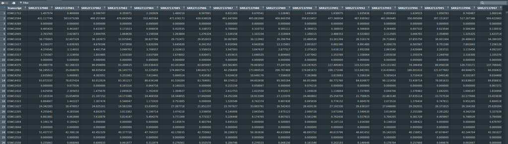

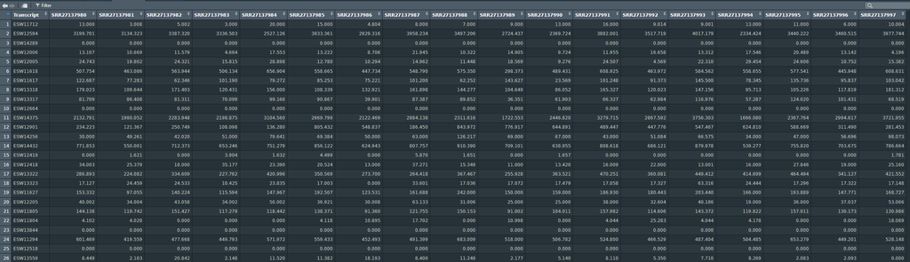

# ===========================================================================

## 2.5 : Verificación de nombres y correspondencia entre archivos y metadatos

# ===========================================================================

```r
# PASO 2: Verificar y guardar
head(colnames(txi$abundance)) #los nombres de las muestras en la matriz
```

```
## [1] "SRR27137980" "SRR27137981" "SRR27137982" "SRR27137983" "SRR27137984"
## [6] "SRR27137985"
```

```r
head(rownames(metadata_df)) #los nombres coinciden y asi se evita errores
```

```
## [1] "SRR27137980" "SRR27137981" "SRR27137982" "SRR27137983" "SRR27137984"
## [6] "SRR27137985"
```

# Sección 3: Análisis exploratorio y diferencial de expresión

# ===========================================================================

## 3.1 Construcción del objeto DESeqDataSet

# ===========================================================================

```r
# Crear DESeqDataSet (desde metadata_df) ara realizar análisis de expresión diferencial txi contiene tus datos crudos de Salmon (matrices de counts y TPM para cada transcrito y muestra) ademas le estamos pasando la tabla de metadatos que describe cada muestra (contiene counts + metadatos + diseño experimental)
#Y se indica que se quiere analizar los efectos de Treatment (RNAi, EV, Ox) y Pi_Status (OPI, LPI) sobre la expresión génica
dds <- DESeqDataSetFromTximport(txi, colData = metadata_df, design = ~ Treatment + Pi_Status)
```

```
## using counts and average transcript lengths from tximport
```

```r
# Normalización para PCA/heatmap por transformación de varianza estabilizada (VST)
vsd <- vst(dds)
```

```
## using 'avgTxLength' from assays(dds), correcting for library size
```

# ===========================================================================

## 3.2 : Análisis exploratorio: PCA

# ===========================================================================

```r
# Visualización de las relaciones globales entre muestras usando Análisis de Componentes Principales (PCA).
# relaciones globales entre muestras y se agrupan según tratamiento o estado de Pi
pca_data <- plotPCA(vsd, intgroup = c("Treatment", "Pi_Status"), returnData = TRUE)
```

```
## using ntop=500 top features by variance
```

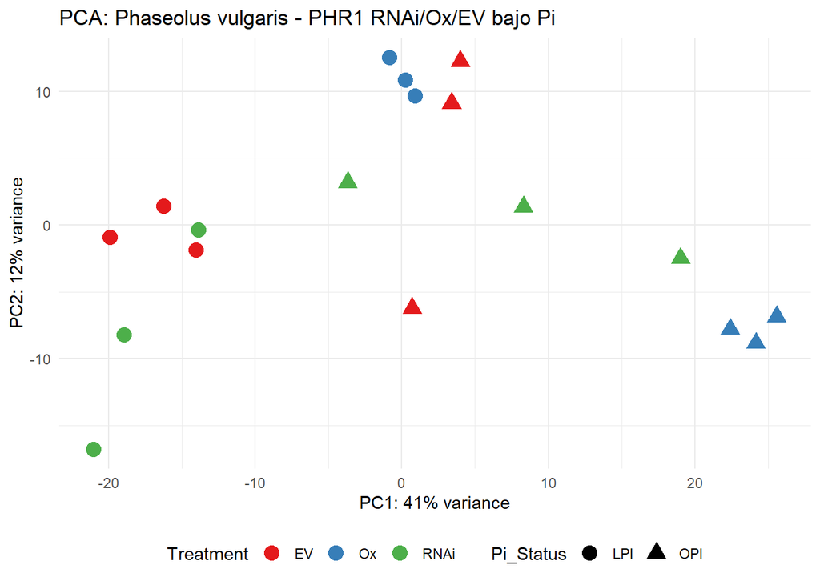

```r
percentVar <- round(100 * attr(pca_data, "percentVar")) #Calcula el porcentaje de varianza explicada por PC1 y PC2, para mostrarlo en los ejes del gráfico.

pca_plot <- ggplot(pca_data, aes(PC1, PC2, color = Treatment, shape = Pi_Status)) +
  geom_point(size = 4) + #dibuja los puntos para cada muestra
  xlab(paste0("PC1: ", percentVar[1], "% variance")) + #muestra en el eje X (PC1) y eje Y (PC2).
  ylab(paste0("PC2: ", percentVar[2], "% variance")) +
  ggtitle("PCA: Phaseolus vulgaris - PHR1 RNAi/Ox/EV bajo Pi") +
  theme_minimal() +
  scale_color_brewer(palette = "Set1") + #estética del gráfico y paleta de colores.
  theme(legend.position = "bottom")
ggsave(here("salidas", "pca_phr1.png"), pca_plot, width = 10, height = 8)

print(pca_plot)
```

```r
# Guardar PCA
dir.create(here("salidas"), showWarnings = FALSE)
ggsave(here("salidas", "pca_phr1.png"), pca_plot, width = 10, height = 8, dpi = 300)
```

# ===========================================================================

# 3.2.1 : Gráfico 3D PCA interactivo

# ===========================================================================

```r
# Calculamos PCA manualmente para incluir PC3
pca <- prcomp(t(assay(vsd)), scale. = FALSE)
pca_data_3d <- data.frame(
  PC1 = pca$x[,1],
  PC2 = pca$x[,2],
  PC3 = pca$x[,3],
  Treatment = colData(vsd)$Treatment,
  Pi_Status = colData(vsd)$Pi_Status
)
percentVar_3d <- round(100 * (pca$sdev^2 / sum(pca$sdev^2))[1:3])

pca_plot_3d <- plot_ly(
  pca_data_3d,
  x = ~PC1,
  y = ~PC2,
  z = ~PC3,
  color = ~Treatment,
  symbol = ~Pi_Status,
  type = "scatter3d",
  mode = "markers",
  marker = list(size = 8)
) %>%
  layout(
    title = "PCA 3D: Phaseolus vulgaris - PHR1 RNAi/Ox/EV bajo Pi",
    scene = list(
      xaxis = list(title = paste0("PC1: ", percentVar_3d[1], "% variance")),
      yaxis = list(title = paste0("PC2: ", percentVar_3d[2], "% variance")),
      zaxis = list(title = paste0("PC3: ", percentVar_3d[3], "% variance"))
    ),
    legend = list(orientation = "h", y = -0.1)
  )

# Guardamos el gráfico 3D como HTML
htmlwidgets::saveWidget(pca_plot_3d, here::here("salidas", "pca_phr1_3d.html"))
cat("Gráfico 3D PCA guardado en:", here::here("salidas", "pca_phr1_3d.html"), "\n")
```

```
## Gráfico 3D PCA guardado en: F:/proyecto_final/proyecto/Proyecto_final_Exploraci-n-de-expresi-n-g-nica-/salidas/pca_phr1_3d.html
```

# ===========================================================================

## 3.3 : Heatmap: Transcritos más variables

# ===========================================================================

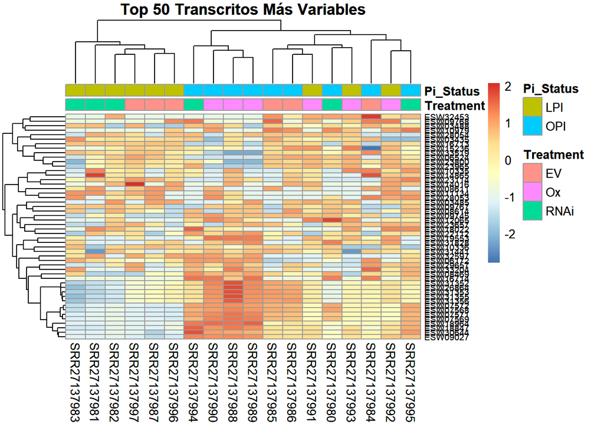

```r
# Top 50 genes más variables
#se toma la matriz de expresión normalizada del objeto vsd (que proviene de DESeq)
#con rowVars calcula la varianza de cada gen y  los ordena
top_var_genes <- head(order(rowVars(assay(vsd)), decreasing = TRUE), 50)
mat <- assay(vsd)[top_var_genes, ]
mat <- t(scale(t(mat)))  # normalización tipo Z-score por fila  por gen

h_top50 <- pheatmap(mat,
         annotation_col = metadata_df[, c("Treatment", "Pi_Status"), drop = FALSE],
         scale = "none",
         clustering_distance_rows = "euclidean", #se agrupan tanto genes como muestras con distancia euclidiana p
         clustering_distance_cols = "euclidean",
         color = colorRampPalette(rev(brewer.pal(n = 7, name = "RdYlBu")))(100),
         main = "Top 50 Transcritos Más Variables",
         fontsize_row = 7)
h_top50
```

```r
dir.create(here("salidas"), showWarnings = FALSE)
ggsave(here("salidas", "heatmap_top50.png"), plot = h_top50, width = 12, height = 10, dpi = 300)
```

# ===========================================================================

## 3.3.1 : Box Plot de la variavilidad de los transcritos

# ===========================================================================

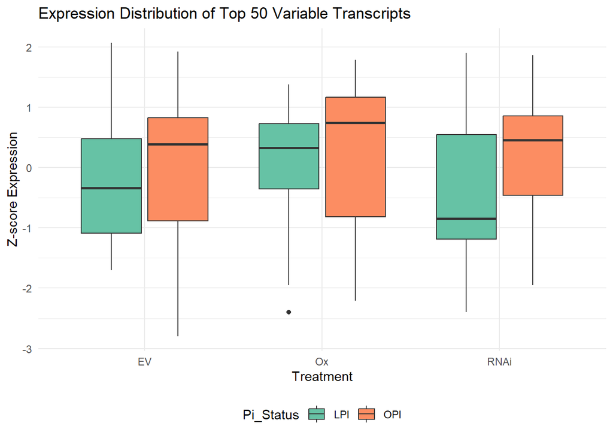

```r
#Convertimosla matriz a formato largo para facilitar su manipulacion con tidyverse
mat_long <- as.data.frame(mat) %>%
  rownames_to_column("Transcript") %>% #Mueve los nombres de fila de genes a una columna llamada transcript
  pivot_longer(cols = -Transcript, names_to = "Sample", values_to = "Z_score") %>% #necesitamos transforma la matriz de formato ancho a largo
  left_join(metadata_df %>% rownames_to_column("Sample"), by = "Sample") #Unecesitamos unirlos metadatos de cada muestra (Treatment, Pi_Status

#
box_plot <- ggplot(mat_long, aes(x = Treatment, y = Z_score, fill = Pi_Status)) +
  geom_boxplot() +
  theme_minimal() +
  labs(title = "Expression Distribution of Top 50 Variable Transcripts",
       x = "Treatment", y = "Z-score Expression") +
  scale_fill_brewer(palette = "Set2") +
  theme(legend.position = "bottom")

#guardar
ggsave(here("salidas", "boxplot_top50.png"), box_plot, width = 10, height = 6, dpi = 300)
print(box_plot)
```

# Sección 4: Generacion de un Mapa

# ===========================================================================

## 4.1 : Seleccion de especies

# ===========================================================================

```r
consulta_A <- name_backbone("Nyctibius grandis") # esta funcion obtiene el resultado que mejor coincida

#vamos a trabajar con una especie del g?nero Pseudoeurycea
#puedes consultar informaci?n en https://enciclovida.mx/especies/25951-pseudoeurycea

consulta_B <- name_backbone("Nyctibius jamaicensis")

consulta_B
```

```
## # A tibble: 1 × 22
##   usageKey scientificName        canonicalName rank  status confidence matchType
## *    <int> <chr>                 <chr>         <chr> <chr>       <int> <chr>
## 1  2496805 Nyctibius jamaicensi… Nyctibius ja… SPEC… ACCEP…         99 EXACT
## # ℹ 15 more variables: kingdom <chr>, phylum <chr>, order <chr>, family <chr>,
## #   genus <chr>, species <chr>, kingdomKey <int>, phylumKey <int>,
## #   classKey <int>, orderKey <int>, familyKey <int>, genusKey <int>,
## #   speciesKey <int>, class <chr>, verbatim_name <chr>
```

```r
consulta_A2 <- name_suggest("Nyctibius grandis")$data

consulta_A2
```

```
## # A tibble: 3 × 3
##       key canonicalName                   rank
##     <int> <chr>                           <chr>
## 1 2496801 Nyctibius grandis               SPECIES
## 2 6176315 Nyctibius grandis guatemalensis SUBSPECIES
## 3 7191304 Nyctibius grandis grandis       SUBSPECIES
```

```r
consulta_B2 <- name_suggest("Nyctibius jamaicensis")$data

consulta_B2
```

```
## # A tibble: 6 × 3
##       key canonicalName                       rank
##     <int> <chr>                               <chr>
## 1 2496805 Nyctibius jamaicensis               SPECIES
## 2 7191301 Nyctibius jamaicensis jamaicensis   SUBSPECIES
## 3 6176319 Nyctibius jamaicensis mexicanus     SUBSPECIES
## 4 6176320 Nyctibius jamaicensis costaricensis SUBSPECIES
## 5 6176322 Nyctibius jamaicensis abbotti       SUBSPECIES
## 6 6176321 Nyctibius jamaicensis lambi         SUBSPECIES
```

```r
# Descarga de ocurrencias -------------------------------------------------

Pse_lep <- occ_search(scientificName = "Nyctibius grandis",
                      hasCoordinate = TRUE,
                      hasGeospatialIssue = FALSE
)$data

Pse_lep
```

```
## # A tibble: 500 × 138
##    key        scientificName  decimalLatitude decimalLongitude issues datasetKey
##    <chr>      <chr>                     <dbl>            <dbl> <chr>  <chr>
##  1 5007557714 Nyctibius gran…           10.5             -83.9 cdc,c… 50c9509d-…
##  2 5007600160 Nyctibius gran…          -12.9             -71.4 cdc,c… 50c9509d-…
##  3 5008089021 Nyctibius gran…           10.5             -83.8 cdc,c… 50c9509d-…
##  4 5036715614 Nyctibius gran…          -11.0             -66.1 cdc,c… 50c9509d-…
##  5 5036878407 Nyctibius gran…          -11.0             -66.1 cdc,c… 50c9509d-…
##  6 5062946758 Nyctibius gran…          -11.0             -66.1 cdc,c… 50c9509d-…
##  7 5063040716 Nyctibius gran…           -4.34            -73.9 cdc,c… 50c9509d-…
##  8 5063043830 Nyctibius gran…           10.4             -83.8 cdc,c… 50c9509d-…
##  9 5063077518 Nyctibius gran…            5.50            -74.6 cdc,c… 50c9509d-…
## 10 5063122137 Nyctibius gran…          -11.0             -68.8 cdc,c… 50c9509d-…
## # ℹ 490 more rows
## # ℹ 132 more variables: publishingOrgKey <chr>, installationKey <chr>,
## #   hostingOrganizationKey <chr>, publishingCountry <chr>, protocol <chr>,
## #   lastCrawled <chr>, lastParsed <chr>, crawlId <int>, basisOfRecord <chr>,
## #   occurrenceStatus <chr>, taxonKey <int>, kingdomKey <int>, phylumKey <int>,
## #   classKey <int>, orderKey <int>, familyKey <int>, genusKey <int>,
## #   speciesKey <int>, acceptedTaxonKey <int>, acceptedScientificName <chr>, …
```

```r
names(Pse_lep)
```

```
##   [1] "key"
##   [2] "scientificName"
##   [3] "decimalLatitude"
##   [4] "decimalLongitude"
##   [5] "issues"
##   [6] "datasetKey"
##   [7] "publishingOrgKey"
##   [8] "installationKey"
##   [9] "hostingOrganizationKey"
##  [10] "publishingCountry"
##  [11] "protocol"
##  [12] "lastCrawled"
##  [13] "lastParsed"
##  [14] "crawlId"
##  [15] "basisOfRecord"
```

[output cut: 123 more lines]

```r
#vamos a explorar algunas variables
unique(Pse_lep$country)
```

```
##  [1] "Costa Rica"                         "Peru"
##  [3] "Bolivia (Plurinational State of)"   "Colombia"
##  [5] "Ecuador"                            "Panama"
##  [7] "Guyana"                             "Suriname"
##  [9] "French Guiana"                      "Brazil"
## [11] "Mexico"                             "Guatemala"
## [13] "Honduras"                           "Nicaragua"
## [15] "Venezuela (Bolivarian Republic of)"
```

```r
#revisar de qu? tipo de registros se trata
unique(Pse_lep$basisOfRecord)
```

```
## [1] "HUMAN_OBSERVATION"   "MACHINE_OBSERVATION"
```

```r
Pse_lep <- Pse_lep %>%
  filter(basisOfRecord %in% c(c("HUMAN_OBSERVATION")))

#Instituci?n que hizo el registro
unique(Pse_lep$institutionCode)
```

```
## [1] "iNaturalist"
## [2] NA
## [3] "NABU|naturgucker"
## [4] "Empresas Públicas de Medellín E.S.P. (EPM)"
## [5] "Frontera Energy Colombia Corp"
## [6] "Petroeléctrica de los Llanos (PEL)"
## [7] "Geopark Colombia S.A.S. (Geopark)"
## [8] "CLO"
```

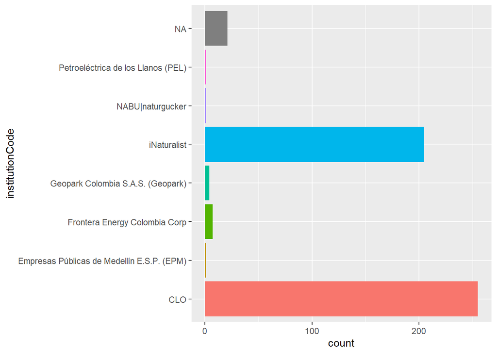

```r
Pse_lep %>%
  ggplot(aes(x= institutionCode, fill= institutionCode))+
  geom_bar()+
  coord_flip()+
  theme(legend.position = "none")
```

```r
#vamos a filtrar los datos que no tienen instituci?n de registro
Pse_lep <- Pse_lep %>%
  filter(!is.na(institutionCode))


#CRS (Coordinate Reference System)
Pse_lep_sp <- Pse_lep %>%
  st_as_sf(coords = c("decimalLongitude", "decimalLatitude"), crs= 4326)

#los CRS tienen c?digos ?nicos que los identifican (ESPG)
#el m?s com?n es el 4326 que corresponde a WGS 84 - WGS84 - Sistema Geod?sico Mundial 1984,
#https://epsg.io/4326

Pse_lep_sp
```

```
## Simple feature collection with 474 features and 136 fields
## Geometry type: POINT
## Dimension:     XY
## Bounding box:  xmin: -90.97078 ymin: -22.86172 xmax: -39.82878 ymax: 16.88824
## Geodetic CRS:  WGS 84
## # A tibble: 474 × 137
##    key        scientificName  issues datasetKey publishingOrgKey installationKey
##  * <chr>      <chr>           <chr>  <chr>      <chr>            <chr>
##  1 5007557714 Nyctibius gran… cdc,c… 50c9509d-… 28eb1a3f-1c15-4… 997448a8-f762-…
##  2 5007600160 Nyctibius gran… cdc,c… 50c9509d-… 28eb1a3f-1c15-4… 997448a8-f762-…
##  3 5008089021 Nyctibius gran… cdc,c… 50c9509d-… 28eb1a3f-1c15-4… 997448a8-f762-…
##  4 5036715614 Nyctibius gran… cdc,c… 50c9509d-… 28eb1a3f-1c15-4… 997448a8-f762-…
##  5 5036878407 Nyctibius gran… cdc,c… 50c9509d-… 28eb1a3f-1c15-4… 997448a8-f762-…
##  6 5062946758 Nyctibius gran… cdc,c… 50c9509d-… 28eb1a3f-1c15-4… 997448a8-f762-…
##  7 5063040716 Nyctibius gran… cdc,c… 50c9509d-… 28eb1a3f-1c15-4… 997448a8-f762-…
##  8 5063043830 Nyctibius gran… cdc,c… 50c9509d-… 28eb1a3f-1c15-4… 997448a8-f762-…
##  9 5063077518 Nyctibius gran… cdc,c… 50c9509d-… 28eb1a3f-1c15-4… 997448a8-f762-…
## 10 5063122137 Nyctibius gran… cdc,c… 50c9509d-… 28eb1a3f-1c15-4… 997448a8-f762-…
## # ℹ 464 more rows
## # ℹ 131 more variables: hostingOrganizationKey <chr>, publishingCountry <chr>,
## #   protocol <chr>, lastCrawled <chr>, lastParsed <chr>, crawlId <int>,
## #   basisOfRecord <chr>, occurrenceStatus <chr>, taxonKey <int>,
## #   kingdomKey <int>, phylumKey <int>, classKey <int>, orderKey <int>,
## #   familyKey <int>, genusKey <int>, speciesKey <int>, acceptedTaxonKey <int>,
## #   acceptedScientificName <chr>, kingdom <chr>, phylum <chr>, order <chr>, …
```

```r
#cargo una capa raster de altitud
alt <- worldclim_global(var="elev", res=5, path=tempdir())

#cargo archivos vectoriales
data(countriesHigh)
#desino un objeto que tiene datos del mundo de manera espacial
Mundo <- st_as_sf(countriesHigh)

##repetimos para la especie
Inc_val <- occ_search(scientificName = "Nyctibius jamaicensis",
                      hasCoordinate = TRUE,
                      hasGeospatialIssue = FALSE
)$data


Inc_val$country %>% unique
```

```
## [1] "Dominican Republic" "Mexico"             "Jamaica"
## [4] "Nicaragua"          "Guatemala"          "Honduras"
## [7] "Belize"             "Costa Rica"         "El Salvador"
```

```r
Inc_val <- Inc_val %>%
  filter(basisOfRecord %in% c(c("HUMAN_OBSERVATION"))) %>%
  filter(!is.na(institutionCode))

Inc_val_sp <- Inc_val %>%
  st_as_sf(coords = c("decimalLongitude", "decimalLatitude"), crs= 4326)
```

# ===========================================================================

## 4.2 : Mapas para especies

# ===========================================================================

```
## <SpatRaster> resampled to 5e+05 cells.
## Ignoring unknown labels:
## • colour : "Especies"
## Scale on map varies by more than 10%, scale bar may be inaccurate
```

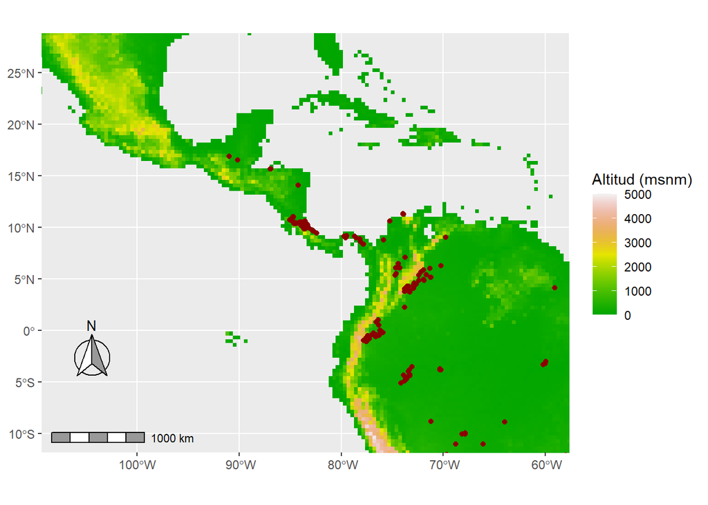

```r
#Mapa simple para la especie
ggplot()+
  geom_spatraster(data= alt)+
  geom_sf(data= Pse_lep_sp, aes(col = species), col="red4")+
  coord_sf(xlim = c(-107, -60), ylim = c(27, -10))+
  scale_fill_paletteer_c("grDevices::terrain.colors",
                         limits = c(0, 5000),
                         na.value = "transparent") +
  annotation_north_arrow(location = "bl",
                       which_north="true",
                       pad_x = unit(0.2, "in"),
                       pad_y = unit(0.7, "in"),
                       style=north_arrow_fancy_orienteering(fill = c("white", "grey60")))+
  annotation_scale(location = "bl",
                   bar_cols = c("grey60", "white"),
                   text_family = "ArcherPro Book")+
  labs(fill= "Altitud (msnm)", col= "Especies")
```

```
## <SpatRaster> resampled to 5e+05 cells.
## Ignoring unknown labels:
## • colour : "Especies"
## Scale on map varies by more than 10%, scale bar may be inaccurate
```

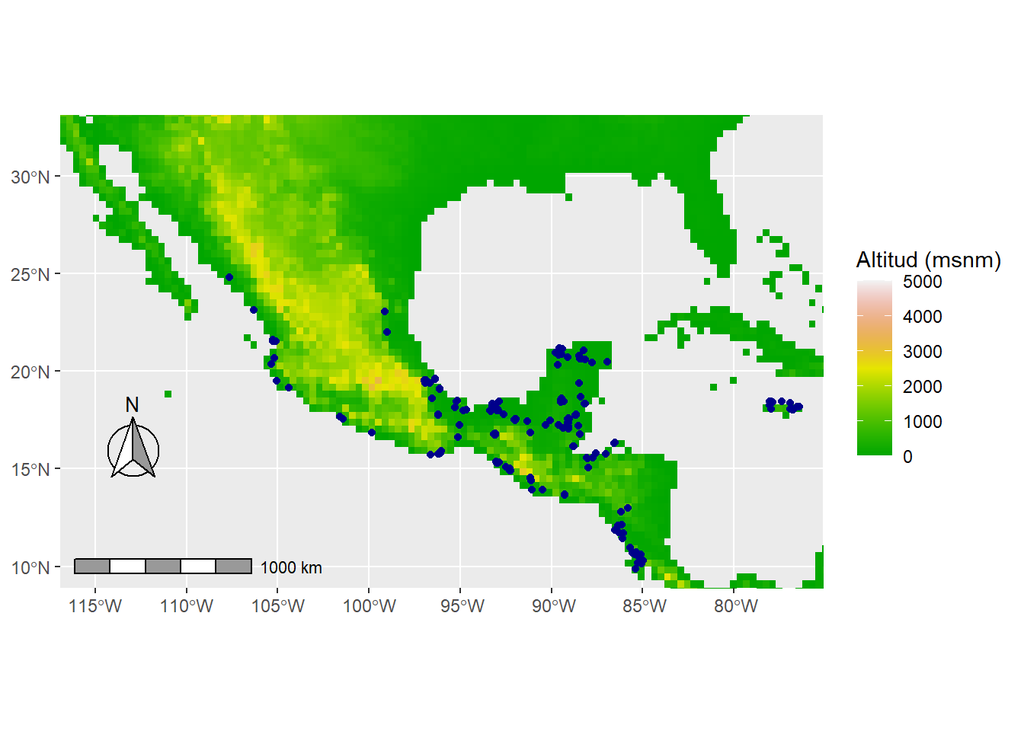

```r
#repetir los pasos para la otra especie


ggplot()+
  geom_spatraster(data= alt)+
  geom_sf(data= Inc_val_sp, aes(col = species), col="blue4")+
  coord_sf(xlim = c(-115, -77), ylim = c(32, 10))+
  scale_fill_paletteer_c("grDevices::terrain.colors",
                         limits = c(0, 5000),
                         na.value = "transparent") +
  annotation_north_arrow(location = "bl",
                       which_north="true",
                       pad_x = unit(0.2, "in"),
                       pad_y = unit(0.7, "in"),
                       style=north_arrow_fancy_orienteering(fill = c("white", "grey60")))+
  annotation_scale(location = "bl",
                   bar_cols = c("grey60", "white"),
                   text_family = "ArcherPro Book")+
  labs(fill= "Altitud (msnm)", col= "Especies")
```

```r
#juntamos los dos mapas
map_occ <-ggplot()+
  geom_spatraster(data= alt, alpha= 0.5)+
  geom_sf(data= Pse_lep_sp, aes(col = species))+
  geom_sf(data= Inc_val_sp, aes(col = species))+
  geom_sf(data= Mundo, fill= NA, linewidth=1)+
  coord_sf(xlim = c(-115, -60), ylim = c(32, -10))+
  scale_color_manual(values = c("#8d62fc", "#fc8d62")) +
  scale_fill_paletteer_c("grDevices::terrain.colors",
                         limits = c(0, 5000),
                         na.value = "transparent")+
  annotation_north_arrow(location = "bl",
                         which_north="true",
                         pad_x = unit(0.2, "in"),
                         pad_y = unit(0.7, "in"),
                         style=north_arrow_fancy_orienteering(fill = c("white", "grey60")))+
  annotation_scale(location = "bl",
                   bar_cols = c("grey60", "white"),
                   text_family = "ArcherPro Book")+
  labs(fill= "Altitud (msnm)", col= "Especies")
```

```
## <SpatRaster> resampled to 5e+05 cells.
```

```
## Scale on map varies by more than 10%, scale bar may be inaccurate
```

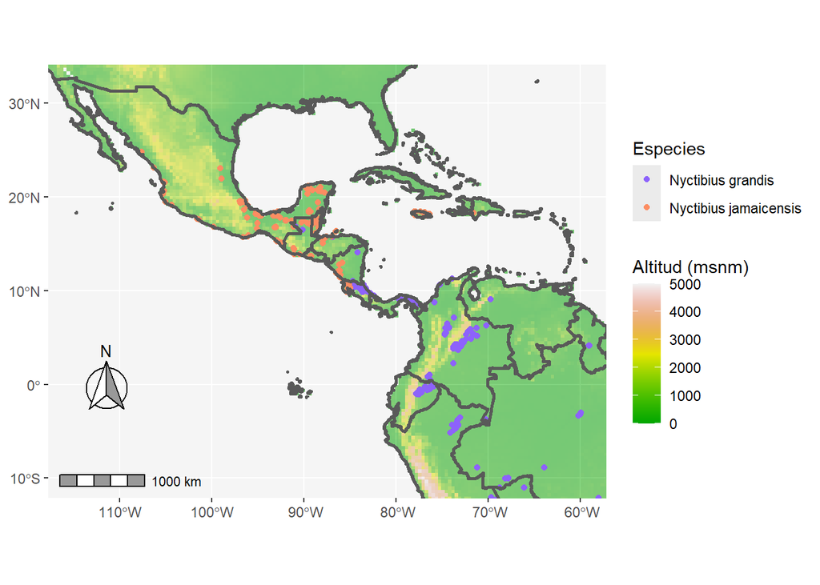

```r
map_occ
```